# 第14回 区分の表を、地図にする

期待度数・カイ二乗・対応分析・全14回の歩み

# 導入

## ここまでの地図とグループ

- 第9・10回：数の列を、主成分の地図に
- 第11・13回：数の列で、国をグループに分けた

## 今日のデータには、数の列がない

- 映画の「ジャンル」と「公開の年代」
- 2つの区分を数えた表だけ

## あなたは、配信の企画担当者

- 「年代別の特集」を組みたい
- どの年代に、どのジャンルを合わせれば、その時代らしさが出るか

## 今日の問い

どの年代に、どのジャンルを合わせれば、その時代らしさが出るか。1枚の地図と数で示せるか？

## 今日のコードの書き方

- これまでの書き方の総ざらい
- 配列の計算、`def`、`for`と辞書、f-string

## この問いに、どう近づくか

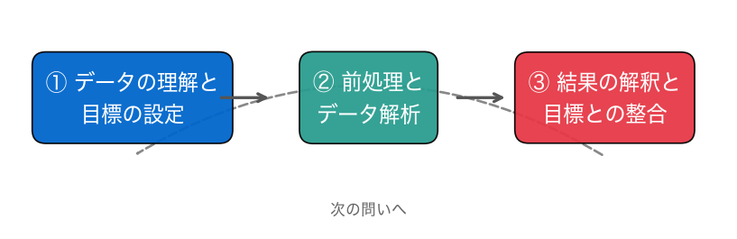

①から③までを、全部回ります。

# 0. 設定

## やってみよう：0節

- 第14回のノートを開き、ドライブにコピーする
- 0節の設定のセルを実行する。`prince`が無ければ、自動で入る

動画の人は、ここで一時停止。

# 1. 関係はあるか

## 地図の前に、関係はあるか

- 年代とジャンルに関係があるかを、まず数で確かめる

## クロス表

- ジャンル（10種類）× 公開の年代（1930〜2010年代）
- 1つのマスが、その映画の本数

## 関係がないなら

- どの年代でも、ジャンルの割合は同じになるはず
- そのとき各マスに入るはずの本数が、期待度数

## カイ二乗

$$\chi^2 = \sum \frac{(\text{実際} - \text{期待})^2}{\text{期待}}$$

- 実際の本数と期待度数のずれを、1つの数に集めたもの

## p値

- 「関係がない」としたとき、これ以上大きなずれが偶然に起きる確率
- 小さいほど、「関係がない」とは考えにくい

## お手本：カイ二乗で確かめる

```python
# データはこのリポジトリから読み込む
DATA_DIR = ('https://raw.githubusercontent.com/k0heiun0/'
            'applied_exercise_preview/main/shared/data')
ct = pd.read_csv(f'{DATA_DIR}/movielens_genre_decade.csv',
                 index_col=0)
ct.columns = ct.columns.astype(str)   # 年代の名前を文字に
print(ct)
chi2, p, dof, E = chi2_contingency(ct)
print(round(chi2, 1), dof, p)
```

- `chi2_contingency`：カイ二乗・p値・自由度・期待度数の4つを返す

## おさらい：配列の計算

```python
a = np.array([1, 2, 3])
a * 10          # すべての要素に、まとめて計算
```

- `for`を書かなくても、まとめて計算できる（第2回）
- `np.outer(a, b)`：aとbを総当たりでかけた表

## TODO①：期待度数を、自分で

```python
# TODO: 期待度数 E2 を自分で計算し、E と一致するか確かめる
# ヒント: n = ct.values.sum()
#         E2 = np.outer(ct.sum(axis=1), ct.sum(axis=0)) / n
#         np.allclose(E, E2)
...
```

- 期待度数 ＝ 行の合計 × 列の合計 ÷ 総数

## やってみよう：1節とTODO①

- 1節のお手本のセルを実行する
- TODO①：期待度数を自分で計算し、`E`と比べる

動画の人は、ここで一時停止。

## 答え合わせ：クロス表

```
           1930  1940  1950  1960  1970  1980  1990  2000  2010
genre
Action        8     8    15    56   103   227   392   549   464
Adventure    13    13    30    65    71   170   239   363   292
Comedy       53    55    67   132   155   492   890  1135   758
Crime        15    29    29    43    70   124   264   404   218
Drama        74   118   146   192   225   439  1038  1365   743
Fantasy       8    11    11    25    31   106   149   252   178
Horror        9    12    25    40    63   176   160   298   190
Romance      48    54    64    60    44   154   422   523   217
Sci-Fi        3     2    35    35    59   156   173   266   244
Thriller     11    32    32    49    95   180   420   654   417
```

## 答え合わせ：カイ二乗

```
548.4 72 1.97641130983306e-74
```

- カイ二乗548.4、p値は10のマイナス74乗ほど

## 年代で、ジャンルは偏っている

- 「関係がない」とすると、こんなに大きなずれはまず起きない
- 年代によって、ジャンルの構成は偏っている
- p値は、偏りがあることを示す。偏りの大きさではない

## 答え合わせ：TODO①

```
True
```

- `chi2_contingency`の中でも、同じ計算をしている

## ロマンスの1930年代

- 期待度数：1586本 × 242本 ÷ 18544本 ≒ 20.7本
- 実際は48本。期待の2倍以上

# 2. 対応分析で、地図に

## 偏りはある。では、どこに？

- カイ二乗で、年代によってジャンルが偏っているとわかった
- どこが偏っているかを、1枚の地図で見る

## ずれの表を、縮める

- 対応分析：「実際 ÷ 期待」のずれの表を、PCAと同じ考え方で縮める（第9回）
- ジャンルも年代も、同じ地図の上に置ける

## 地図の読み方

- 同じ向きに原点から離れたジャンルと年代
- 「その年代に、そのジャンルが多い」関係
- これは読む目安。確かな多さは、3節で「実際 ÷ 期待」を数で見る

## おさらい：def

```python
def 名前(引数):
    return 戻り値
```

- `def`の後ろが名前と引数（入力）、`return`の後ろが戻り値（出力）（第3回）
- 地図を描く手順は、課題でも使うので関数にする

## お手本：対応分析をかける

```python
ca = prince.CA(n_components=2, random_state=42).fit(ct)
rows = ca.row_coordinates(ct)                # ジャンルの座標
cols = ca.column_coordinates(ct)             # 年代の座標
```

- `row_coordinates`：行（ジャンル）、`column_coordinates`：列（年代）

## お手本：地図を描く関数

```python
def draw_ca(ax, rows, cols):         # ジャンルは青、年代は赤
    ax.scatter(rows[0], rows[1], color='#0066cc', s=60)
    for name, (x, y) in rows.iterrows():
        ax.text(x, y, ' ' + name, color='#0066cc', fontsize=10)
    ax.scatter(cols[0], cols[1], color='#e63946', marker='^', s=60)
    for name, (x, y) in cols.iterrows():
        ax.text(x, y, ' ' + name, color='#e63946', fontsize=10)
    ax.axhline(0, color='gray', lw=0.5)       # 原点を通る線
    ax.axvline(0, color='gray', lw=0.5)
    ax.set_xlabel('次元1'); ax.set_ylabel('次元2')

fig, ax = plt.subplots(figsize=(8, 6))
draw_ca(ax, rows, cols)
plt.show()
```

## TODO②：寄与率

```python
# TODO: 次元1・次元2の寄与率を表示する
# ヒント: ca.eigenvalues_summary、または ca.percentage_of_variance_
...
```

## やってみよう：2節とTODO②

- 2節のお手本のセルを実行する
- TODO②：2本の軸で、全体の何割を表せているか？

動画の人は、ここで一時停止。

## 答え合わせ：TODO②

```
          eigenvalue % of variance % of variance (cumulative)
component
0              0.020        67.26%                     67.26%
1              0.005        16.64%                     83.90%
```

- 次元1が67.3%、2本で83.9%。かなり信頼して読める

## まず、年代だけ

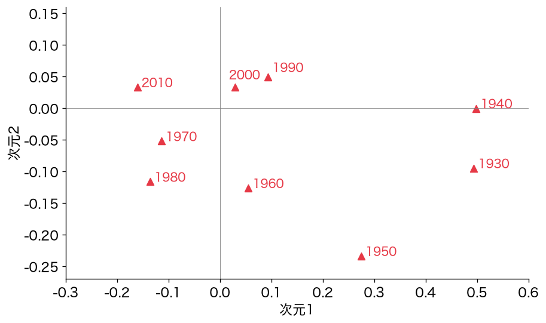

- 年代は、横にどう並んでいるか？

## 次元1は、時代の軸

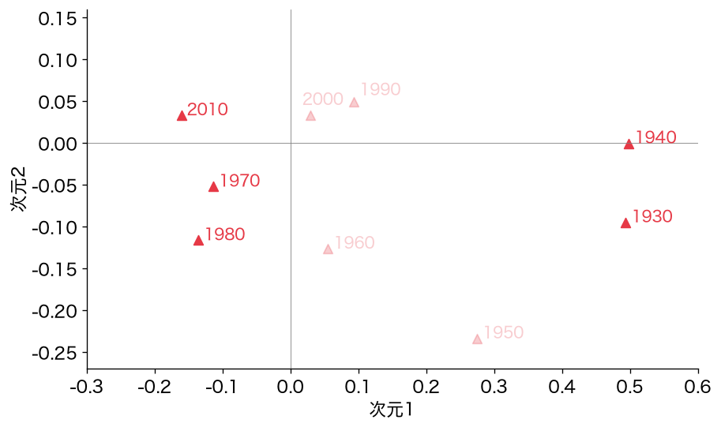

- 1930・1940年代が右の端（0.5前後）。1970・1980・2010年代が左

## 1990・2000年代は、原点の近く

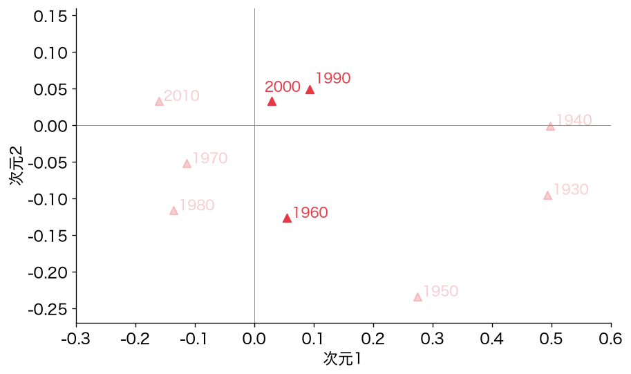

- 1990年代（＋0.09）は、1960年代（＋0.06）より右
- 「右が古く、左が新しい」と言えるのは、両端だけ

## お手本：年代ごとの本数の割合

```python
share = ct.sum() / ct.values.sum()     # 年代ごとの、本数の割合
print(share.round(3))
```

```
1930    0.013
1940    0.018
1950    0.024
1960    0.038
1970    0.049
1980    0.120
1990    0.224
2000    0.313
2010    0.201
```

## 本数の多い年代は、平均に近い

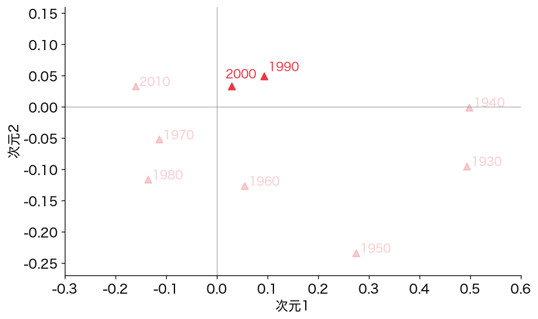

- 1990・2000年代で、全体の54%
- 原点は全体の平均。本数が多いと、原点に近づく

## ジャンルを重ねる

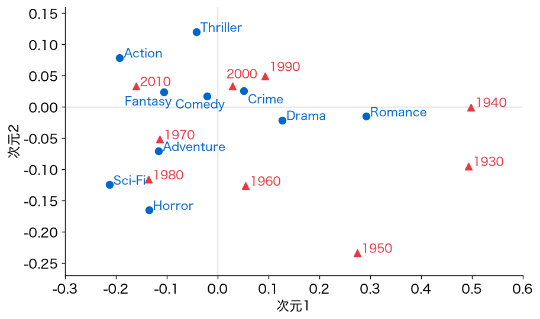

## 古い年代の側

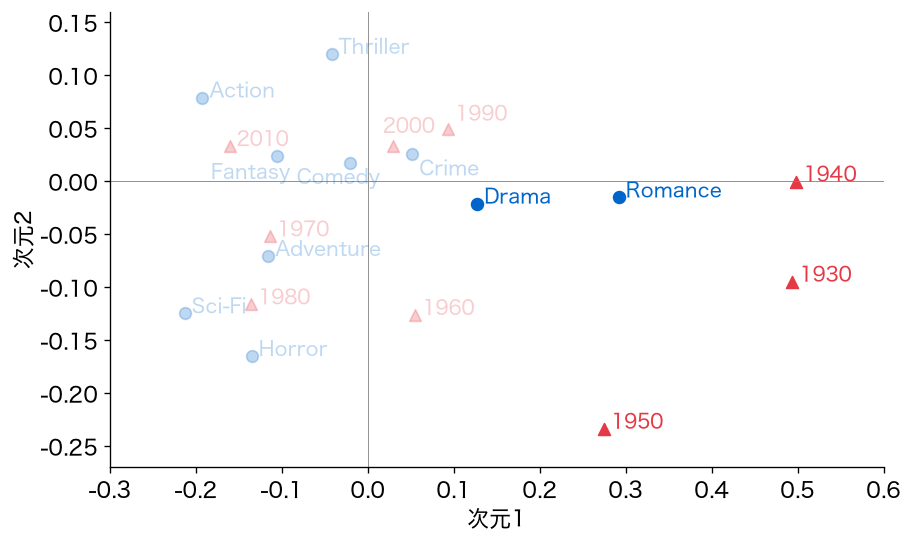

- ロマンスとドラマが、古い年代の側

## 新しい年代の側

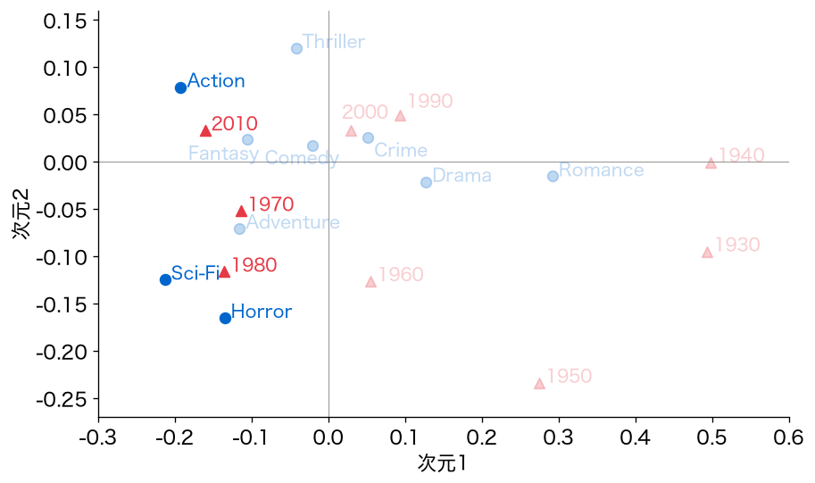

- SF・アクション・ホラーが、新しい年代の側

## 原点の近くは、定番

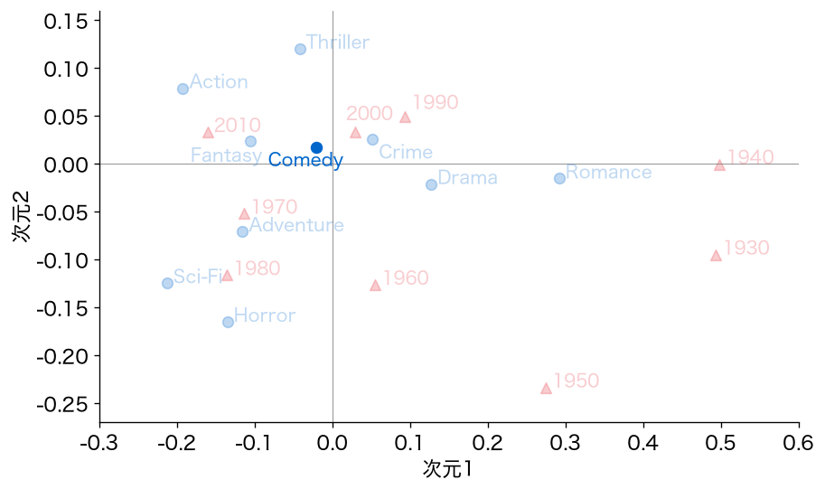

- コメディは原点の近く。どの年代にも同じくらいある

# 3. 答えを出す

## 地図の読みを、数で確かめる

- 各マスの「実際 ÷ 期待」の倍率
- 1より大きければ、その年代らしいジャンル

## お手本：倍率の表

```python
ratio = (ct / E).round(2)      # 1 より大きいほど、その年代に多い
print(ratio[['1930', '1940', '1980', '2010']])
```

- 表どうしの割り算も、マスごとにまとめて計算される

## おさらい：forと辞書

```python
d = {}
for i in range(3):
    d[i] = i * 10        # d は {0: 0, 1: 10, 2: 20}
```

- `for`で取り出し、辞書にキーと値をためる（第13回）

## TODO③：上位3ジャンル

```python
# TODO: 1950・1970年代の、倍率の高い3ジャンルを辞書 top3 にためる
# ヒント: top3 = {} → for dec in ['1950', '1970']: の中で
#         s = ratio[dec].sort_values(ascending=False)
#         top3[dec] = s.head(3).to_dict()
...
```

## おさらい：f-string

```python
n = 3
print(f'{n}個')     # 3個
```

- `{}`に、値を埋めこめる（第4回）

## TODO④：企画書を、一文で

```python
# TODO: 1960年代の倍率が最も高い・低いジャンルで、企画書の一文を作る
# ヒント: r = ratio['1960'].sort_values()
#         いちばん高いのは r.index[-1]、倍率は r.iloc[-1]
#         いちばん低いのは r.index[0]
...
```

## やってみよう：3節とTODO③④

- 3節のお手本のセルを実行する
- TODO③：上位3ジャンル。TODO④：企画書の一文

動画の人は、ここで一時停止。

## 答え合わせ：倍率の表

```
           1930  1940  1980  2010
genre
Action     0.34  0.24  1.04  1.27
Adventure  0.79  0.57  1.13  1.16
Comedy     1.09  0.82  1.10  1.01
Crime      0.96  1.35  0.86  0.91
Drama      1.31  1.51  0.84  0.85
Fantasy    0.80  0.79  1.15  1.15
Horror     0.71  0.68  1.51  0.97
Romance    2.32  1.89  0.81  0.68
Sci-Fi     0.24  0.11  1.34  1.25
Thriller   0.45  0.94  0.79  1.10
```

## 古い年代

- 1930年代のロマンス：期待の2.32倍
- 1940年代は、ロマンス（1.89倍）に次いでドラマ：1.51倍

## 新しい年代

- 1980年代のホラー：1.51倍
- 2010年代のアクション：1.27倍、SF：1.25倍
- 地図の読みと、合っている

## 答え合わせ：TODO③

```
1950 {'Romance': 1.65, 'Sci-Fi': 1.47, 'Drama': 1.37}
1970 {'Horror': 1.31, 'Sci-Fi': 1.23, 'Crime': 1.18}
```

## 1950年代と1970年代

- 1950年代：まだロマンスとドラマ。SFが伸びはじめる
- 1970年代：ロマンスが減り、ホラーとSFの時代

## 答え合わせ：TODO④

```
1960年代の特集は Adventure（1.38倍）を中心に。Thriller（0.69倍）は少なめでよい。
```

- 1960年代らしいのは、冒険もの

## 企画担当者の答え

古い年代の特集にはロマンスとドラマ、1980年代にはホラー、2010年代にはアクションとSFを合わせると、その時代らしさが出る。コメディはどの年代にも合う定番。

## まだ言えないこと①：本数と人気

- 数えたのは作られた本数で、見られた回数ではない
- 特集で視聴が伸びるかは、別のデータで確かめる

## まだ言えないこと②：3つ以上

- ジャンル・年代・国のように、区分が3つ以上になったら（発展）

# まとめ

## 今日の歩み

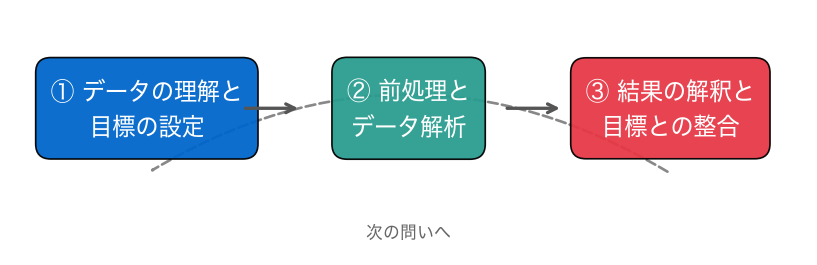

カイ二乗 → 対応分析の地図 → 倍率で確かめる → 答え

## 今日の要点

- 期待度数は、行の合計 × 列の合計 ÷ 総数。カイ二乗は、実際と期待のずれ
- 対応分析は、ずれの表を縮め、行と列を同じ地図に置く
- 同じ向きに離れた行と列は、「その列に、その行が多い」関係
- 地図の読みは、「実際 ÷ 期待」の倍率で数でも確かめる
- Python：配列の計算、`def`、`for`と辞書、f-stringを組み合わせる

# 全14回の歩み

## 今日も、①から③を一周した

- 特集という目標を立て、地図と倍率で解析し、企画の答えを出した
- ここで、全14回をふり返る

## どの回も、同じ一周

- ① 目標を立てる → ② 解析する → ③ 目標に立ち返る
- 題材は、自転車・住宅・心臓病・ペンギン・顔・車・国・映画

## ラベルがあるとき（第1〜8回）

- データを見る → 回帰と汎化 → 前処理 → 評価と解釈 → 正則化
- 分類 → パイプラインとしきい値 → 総合演習
- 当てる・測る・しきい値を決める

## ラベルがないとき（第9〜14回）

- PCA → PCAの読み解き → クラスタリング
- 研究のコード → クラスタリングの妥当性 → 対応分析
- 縮める・分ける・地図にする

## 書き方も、積み上げてきた

- 配列、`for`、`if`、`def`、辞書、f-string
- クラスとメソッド、行列の計算、`while`、関数に分けたスクリプト
- 他人のコードをブロックで読み、いろいろな形式のファイルを読む

## 変わらない姿勢

- 物差しは、判断の材料
- 目的に照らして答えを出し、まだ言えないことを正直に書く

## 課題の出し方

- ノートの最後の「課題（提出）」に取り組む
- 応用②の答えと応用③の文章を、LACSに入力して提出（＝出席。期限なし）
- AIを使ってもよい。何を聞いて、どう直したかを1行書く

## 次回予告：最終討論

- 次回は、最終討論
- これまでの分析から1つを選ぶ

## 次回の問い

選んだ分析の一周と、まだ言えないことを、自分の言葉で説明できるか？

## このあと：課題へ

ノートの「課題（提出）」へ。1990年代以降に絞ると、地図はどう変わるか。